# homework-03

https://github.com/Zach-Tech/ENVS-193DS_homework-03.git

```r
# Load required libraries
library(tidyverse)
library(here)
library(gt)
library(janitor)
library(readxl)
```

## Problem 1a. Data Summarizing (5 points)

To compare my response variable—**number of steps per day**—between different **days of the week**, I could calculate the **mean number of steps** for each day. This would allow me to identify patterns, such as whether I am more active on weekdays compared to weekends.

This comparison is informative because my schedule varies during the week. For example, I have back-to-back classes on Monday and Wednesday, which usually requires more walking, whereas I tend to stay home on Sundays, resulting in fewer steps.

# Load the data

```r
data <- read_csv(here("data", "personal_data.csv"))
```

## Problem 1b. Visualization (10 points)

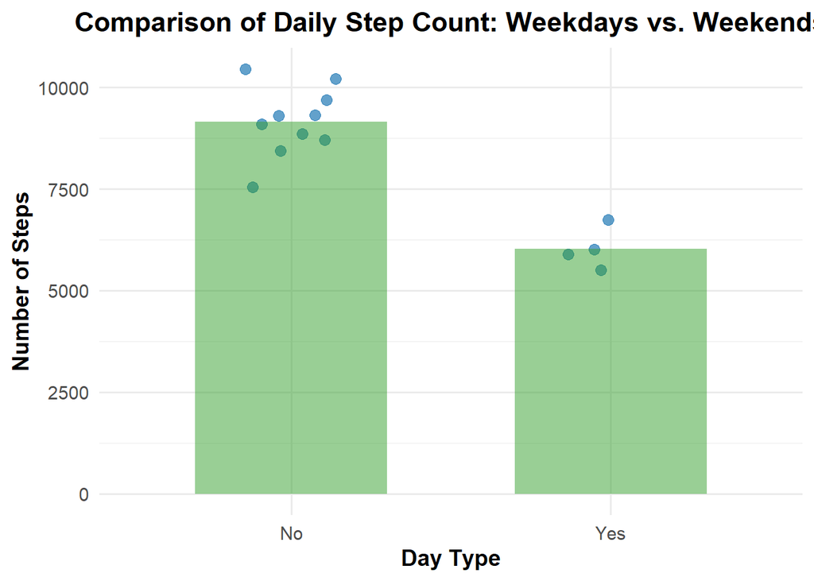

```r
# Summarize: calculate mean steps by weekend vs weekday
library(dplyr)
library(ggplot2)

steps_summary <- data %>%
  group_by(is_weekend) %>%
  summarize(mean_steps = mean(steps), .groups = "drop")

# Plot: points for individual observations + bar for mean
ggplot(data, aes(x = is_weekend, y = steps)) +
  geom_jitter(width = 0.15, size = 3, alpha = 0.7, color = "#1f78b4") +  # individual data
  geom_col(data = steps_summary, aes(x = is_weekend, y = mean_steps),
           fill = "#33a02c", alpha = 0.5, width = 0.6) +  # mean bars
  labs(
    title = "Comparison of Daily Step Count: Weekdays vs. Weekends",
    x = "Day Type",
    y = "Number of Steps"
  ) +
  theme_minimal(base_size = 14) +
  theme(
    plot.title = element_text(face = "bold", hjust = 0.5),
    axis.title.x = element_text(face = "bold"),
    axis.title.y = element_text(face = "bold")
  )
```

## Figure 1. Daily step counts separated by weekdays and weekends. Each point represents the number of steps taken on a specific day, while the bars represent the average (mean) step count for each category. The data show that, on average, more steps were taken on weekdays than weekends, likely due to a more structured schedule including classes and commuting.

```r
## Problem 1d. Table Presentation (10 points)

library(gt)

# Create table from summary
steps_summary %>%
  mutate(mean_steps = round(mean_steps, 1)) %>%  # round to 1 decimal
  gt() %>%
  tab_header(
    title = "Average Daily Step Count",
    subtitle = "Comparison of Mean Steps on Weekdays vs. Weekends"
  ) %>%
  cols_label(
    is_weekend = "Day Type",
    mean_steps = "Mean Number of Steps"
  ) %>%
  tab_options(
    table.font.size = 14,
    heading.title.font.size = 16,
    heading.subtitle.font.size = 14
  )
```

Average Daily Step Count

Comparison of Mean Steps on Weekdays vs. Weekends

| Day Type | Mean Number of Steps |
| --- | --- |
| No | 9160.0 |
| Yes | 6032.5 |

## Problem 2a. Affective Visualization Description

An affective visualization of my personal data could take the form of a color-coded spiral that maps my daily mood using warm and cool tones. Each loop in the spiral would represent one week, with dots or segments sized by how many steps I took that day and shaded by how many hours I slept. The center would start with the earliest week and spiral outward with each passing day. I might use red for low moods and blue or green for more positive moods to evoke an emotional response. This form of visualization would help viewers feel the rhythm of my week—the fluctuations in energy, rest, and emotion—rather than just read it from a chart.

##Code for Dataset Generation

```r
library(tibble)
library(readr)
library(here)

data <- tibble(
  date = as.Date("2025-05-12") + 0:13,
  steps = c(6543, 7021, 8120, 4402, 6051, 10032, 9211,
            7421, 5120, 8301, 6003, 4555, 11032, 10567),
  sleep_hours = c(6.5, 7.2, 6.8, 5.9, 6.0, 8.0, 7.5,
                  6.4, 5.5, 7.1, 6.0, 6.3, 8.5, 7.8),
  mood = c(3, 4, 4, 2, 3, 5, 4, 3, 2, 4, 3, 2, 5, 5),
  is_weekend = weekdays(as.Date("2025-05-12") + 0:13) %in% c("Saturday", "Sunday")
)

# Save to your data folder
write_csv(data, here("data", "personal2_data.csv"))
```

### Problem 2b. Sketch of Affective Visualization

Here is a sketch of my affective data visualization idea:

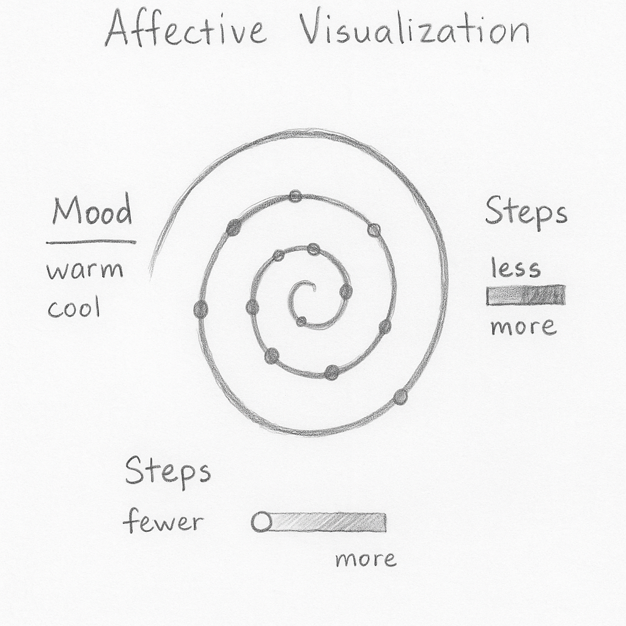